# Hypothesis Testing - Two Categorical Variables

## Parametric Statistics

These are statistics that are used when the sampling distribution is normal distributed.

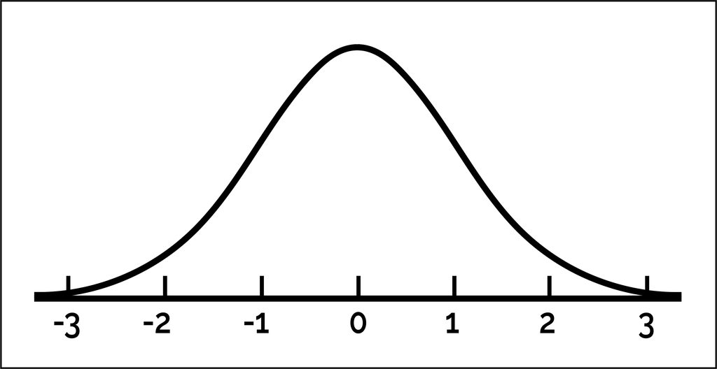

image: Data Science Universe

## Non-Parametric Statistics

These are statistics that are used when the sampling distribution is not normal distributed.

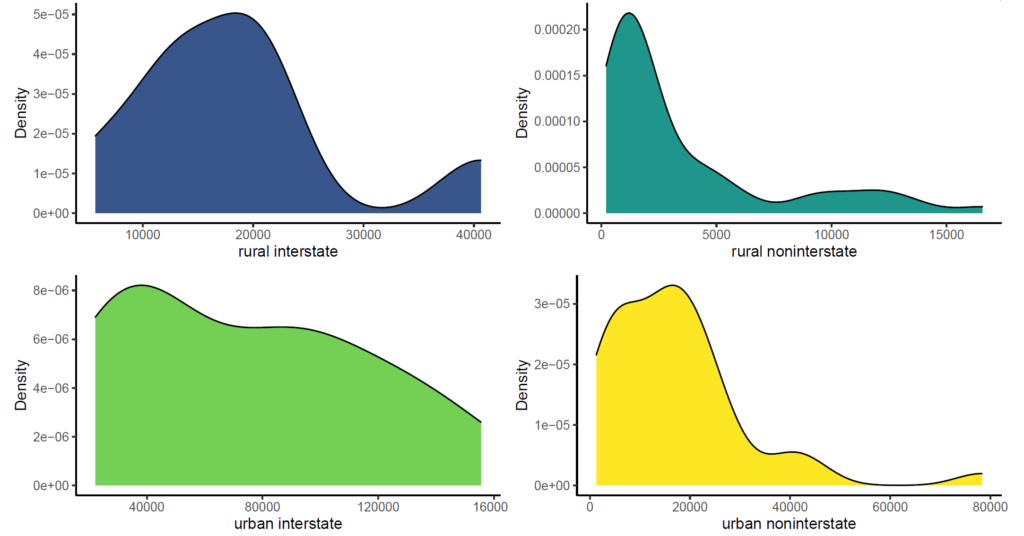

image: Data Science Universe

## Statistical Significance

This is a claim that a set of observations are not due to random chance.

Used in hypothesis testing to help decide whether to reject the null hypothesis.

Leads to a lot of problems within research when relied on.

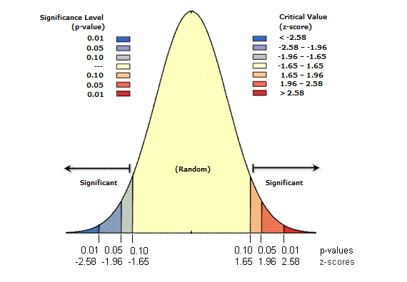

image: arcmap

## Chi Square

This is used when the IV and DV are both categorical and the data is not normally distributed (i.e., non-parametric).

$$x^2 = \frac{\sum (O - E)^2}{E}$$

O = Observed frequency

E = Expected frequency

$$E = \frac{(row \, total)(column \, total)}{(sample \, size)}$$

## Chi-Square Example

Is gender and education level dependent at a 5% level of significance?

In other words, in the data below, is there a relationship between the gender of an individual and the level of education that they have obtained?

|  | High School | Bachelors | Masters | Total |
| --- | --- | --- | --- | --- |
| Female | 60 | 54 | 46 | 160 |
| Male | 40 | 44 | 53 | 137 |
| Total | 100 | 98 | 99 | 297 |

## Chi-Square Example

Let’s first state our null and alternative hypothesis:

$H_0$ Gender and education level are independent, there is no relationship between gender and education level.

$H_A$ Gender and education level are dependent, there is a relationship between gender and education level.

## Chi-Square Example

$$E = \frac{(row \, total)(column \, total)}{(sample \, size)}$$

|  | High School | Bachelors | Masters | Total |
| --- | --- | --- | --- | --- |
| Female | $\frac{(160)(100)}{297}$ | $\frac{(160)(98)}{297}$ | $\frac{(160)(99)}{297}$ | 160 |
| Male | $\frac{(137)(100)}{297}$ | $\frac{(137)(98)}{297}$ | $\frac{(137)(99)}{297}$ | 137 |
| Total | 100 | 98 | 99 | 297 |

## Chi-Square Example

Observed

|  | High School | Bachelors | Masters |
| --- | --- | --- | --- |
| Female | 60 | 54 | 46 |
| Male | 40 | 44 | 53 |

Expected

[output not shown]

## Degrees of Freedom

The degrees of freedom for the chi-square are calculated using the following formula:

$$df = (r-1)(c-1)$$

r = row number

c = column number

## Chi-Square Example

Now, we need to compare this value to the critical value from the chi-square distribution at a 5% significance level.

$$(2−1)×(3−1) = 2$$

2 degrees of freedom

If the observed chi-square test statistic is greater than the critical value, the null hypothesis can be rejected.

If the observed chi-square test statistic is less than the critical value, we fail to reject the null hypothesis.

## Chi-Square Example

The critical value is 5.99

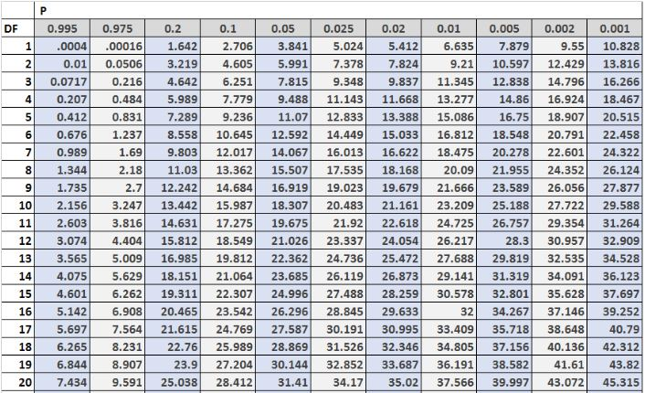

## Chi-Square Example

The critical value = 5.99

Therefore, at a 5% significance level, we do not have enough evidence to conclude that there is a relationship between gender and education level.